# matplotlib.figure

`matplotlib.figure` implements the following classes:

**`Figure`**

Top level `Artist`, which holds all plot elements. Many methods are implemented in `FigureBase`.

**`SubFigure`**

A logical figure inside a figure, usually added to a figure (or parent `SubFigure`) with `Figure.add_subfigure` or `Figure.subfigures` methods (provisional API v3.4).

Figures are typically created using pyplot methods `figure`, `subplots`, and `subplot_mosaic`.

```
fig, ax = plt.subplots(figsize=(2, 2), facecolor='lightskyblue',
                       layout='constrained')
fig.suptitle('Figure')
ax.set_title('Axes', loc='left', fontstyle='oblique', fontsize='medium')
```

([`Source code`](https://matplotlib.org/stable/_downloads/3928de11b4fbd0ba3f492ed92aebda79/figure_api-1.py), [`2x.png`](https://matplotlib.org/stable/_downloads/37981875abad13945405683f462a9931/figure_api-1.2x.png), [`png`](https://matplotlib.org/stable/_downloads/38bf68f42cdd9788ce147da6927a8a7d/figure_api-1.png))

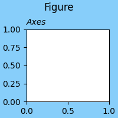

Some situations call for directly instantiating a `Figure` class, usually inside an application of some sort (see [Embedding Matplotlib in graphical user interfaces](https://matplotlib.org/stable/gallery/user_interfaces/index.html#user-interfaces) for a list of examples) . More information about Figures can be found at [Introduction to Figures](https://matplotlib.org/stable/users/explain/figure/figure_intro.html#figure-intro).

## Figure

### Figure class

| `Figure` | The top level container for all the plot elements. |
| --- | --- |

### Adding Axes and SubFigures

| `Figure.add_axes` | Add an `Axes` to the figure. |
| --- | --- |
| `Figure.add_subplot` | Add an `Axes` to the figure as part of a subplot arrangement. |
| `Figure.subplots` | Add a set of subplots to this figure. |
| `Figure.subplot_mosaic` | Build a layout of Axes based on ASCII art or nested lists. |
| `Figure.add_gridspec` | Low-level API for creating a `GridSpec` that has this figure as a parent. |
| `Figure.get_axes` | List of Axes in the Figure. |
| `Figure.axes` | List of Axes in the Figure. |
| `Figure.delaxes` | Remove the `Axes` *ax* from the figure; update the current Axes. |
| `Figure.subfigures` | Add a set of subfigures to this figure or subfigure. |
| `Figure.add_subfigure` | Add a `SubFigure` to the figure as part of a subplot arrangement. |

### Saving

| `Figure.savefig` | Save the current figure as an image or vector graphic to a file. |
| --- | --- |

### Annotating

| `Figure.colorbar` | Add a colorbar to a plot. |
| --- | --- |
| `Figure.legend` | Place a legend on the figure. |
| `Figure.text` | Add text to figure. |
| `Figure.suptitle` | Add a centered suptitle to the figure. |
| `Figure.get_suptitle` | Return the suptitle as string or an empty string if not set. |
| `Figure.supxlabel` | Add a centered supxlabel to the figure. |
| `Figure.get_supxlabel` | Return the supxlabel as string or an empty string if not set. |
| `Figure.supylabel` | Add a centered supylabel to the figure. |
| `Figure.get_supylabel` | Return the supylabel as string or an empty string if not set. |
| `Figure.align_labels` | Align the xlabels and ylabels of subplots with the same subplots row or column (respectively) if label alignment is being done automatically (i.e. the label position is not manually set). |
| `Figure.align_xlabels` | Align the xlabels of subplots in the same subplot row if label alignment is being done automatically (i.e. the label position is not manually set). |
| `Figure.align_ylabels` | Align the ylabels of subplots in the same subplot column if label alignment is being done automatically (i.e. the label position is not manually set). |
| `Figure.align_titles` | Align the titles of subplots in the same subplot row if title alignment is being done automatically (i.e. the title position is not manually set). |
| `Figure.autofmt_xdate` | Date ticklabels often overlap, so it is useful to rotate them and right align them. |

### Figure geometry

| `Figure.set_size_inches` | Set the figure size in inches. |
| --- | --- |
| `Figure.get_size_inches` | Return the current size of the figure in inches. |
| `Figure.set_figheight` | Set the height of the figure in inches. |
| `Figure.get_figheight` | Return the figure height in inches. |
| `Figure.set_figwidth` | Set the width of the figure in inches. |
| `Figure.get_figwidth` | Return the figure width in inches. |
| `Figure.dpi` | The resolution in dots per inch. |
| `Figure.set_dpi` | Set the resolution of the figure in dots-per-inch. |
| `Figure.set_dpi` | Set the resolution of the figure in dots-per-inch. |

### Subplot layout

| `Figure.subplots_adjust` | Adjust the subplot layout parameters. |
| --- | --- |
| `Figure.set_layout_engine` | Set the layout engine for this figure. |
| `Figure.get_layout_engine` |  |

#### Discouraged or deprecated

| `Figure.tight_layout` | Adjust the padding between and around subplots. |
| --- | --- |
| `Figure.set_tight_layout` | [*Deprecated*] Set whether and how `Figure.tight_layout` is called when drawing. |
| `Figure.get_tight_layout` | Return whether `Figure.tight_layout` is called when drawing. |
| `Figure.set_constrained_layout` | [*Deprecated*] Set whether `constrained_layout` is used upon drawing. |
| `Figure.get_constrained_layout` | Return whether constrained layout is being used. |
| `Figure.set_constrained_layout_pads` | [*Deprecated*] Set padding for `constrained_layout`. |
| `Figure.get_constrained_layout_pads` | [*Deprecated*] Get padding for `constrained_layout`. |

### Interactive

See also

- [Event handling and picking](https://matplotlib.org/stable/users/explain/figure/event_handling.html#event-handling)

| `Figure.ginput` | Blocking call to interact with a figure. |
| --- | --- |
| `Figure.add_axobserver` | Whenever the Axes state change, `func(self)` will be called. |
| `Figure.waitforbuttonpress` | Blocking call to interact with the figure. |
| `Figure.pick` | Process a pick event. |

### Modifying appearance

| `Figure.set_frameon` | Set the figure's background patch visibility, i.e. whether the figure background will be drawn. |
| --- | --- |
| `Figure.get_frameon` | Return the figure's background patch visibility, i.e. whether the figure background will be drawn. |
| `Figure.set_linewidth` | Set the line width of the Figure rectangle. |
| `Figure.get_linewidth` | Get the line width of the Figure rectangle. |
| `Figure.set_facecolor` | Set the face color of the Figure rectangle. |
| `Figure.get_facecolor` | Get the face color of the Figure rectangle. |
| `Figure.set_edgecolor` | Set the edge color of the Figure rectangle. |
| `Figure.get_edgecolor` | Get the edge color of the Figure rectangle. |

### Adding and getting Artists

| `Figure.add_artist` | Add an `Artist` to the figure. |
| --- | --- |
| `Figure.get_children` | Get a list of artists contained in the figure. |
| `Figure.figimage` | Add a non-resampled image to the figure. |

### Getting and modifying state

See also

- [Interactive figures](https://matplotlib.org/stable/users/explain/figure/interactive.html#interactive-figures)

| `Figure.clear` | Clear the figure. |
| --- | --- |
| `Figure.gca` | Get the current Axes. |
| `Figure.sca` | Set the current Axes to be *a* and return *a*. |
| `Figure.get_tightbbox` | Return a (tight) bounding box of the figure *in inches*. |
| `Figure.get_window_extent` | Get the artist's bounding box in display space. |
| `Figure.show` | If using a GUI backend with pyplot, display the figure window. |
| `Figure.set_canvas` | Set the canvas that contains the figure |
| `Figure.draw` | Draw the Artist (and its children) using the given renderer. |
| `Figure.draw_without_rendering` | Draw the figure with no output. |
| `Figure.draw_artist` | Draw `Artist` *a* only. |

## SubFigure

Matplotlib has the concept of a `SubFigure`, which is a logical figure inside a parent `Figure`. It has many of the same methods as the parent. See [Nested Axes layouts](https://matplotlib.org/stable/users/explain/axes/arranging_axes.html#nested-axes-layouts).

([`Source code`](https://matplotlib.org/stable/_downloads/382c9b85341197b76d986e481c645d41/figure_api-2.py), [`2x.png`](https://matplotlib.org/stable/_downloads/da916275b47491944b59f7675d56ce3e/figure_api-2.2x.png), [`png`](https://matplotlib.org/stable/_downloads/6d2d947373c1c37fbc4b6d0d0e4f83d9/figure_api-2.png))

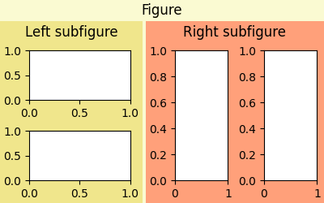

### SubFigure class

| `SubFigure` | Logical figure that can be placed inside a figure. |
| --- | --- |

### Adding Axes and SubFigures

| `SubFigure.add_axes` | Add an `Axes` to the figure. |
| --- | --- |
| `SubFigure.add_subplot` | Add an `Axes` to the figure as part of a subplot arrangement. |
| `SubFigure.subplots` | Add a set of subplots to this figure. |
| `SubFigure.subplot_mosaic` | Build a layout of Axes based on ASCII art or nested lists. |
| `SubFigure.add_gridspec` | Low-level API for creating a `GridSpec` that has this figure as a parent. |
| `SubFigure.delaxes` | Remove the `Axes` *ax* from the figure; update the current Axes. |
| `SubFigure.add_subfigure` | Add a `SubFigure` to the figure as part of a subplot arrangement. |
| `SubFigure.subfigures` | Add a set of subfigures to this figure or subfigure. |

### Annotating

| `SubFigure.colorbar` | Add a colorbar to a plot. |
| --- | --- |
| `SubFigure.legend` | Place a legend on the figure. |
| `SubFigure.text` | Add text to figure. |
| `SubFigure.suptitle` | Add a centered suptitle to the figure. |
| `SubFigure.get_suptitle` | Return the suptitle as string or an empty string if not set. |
| `SubFigure.supxlabel` | Add a centered supxlabel to the figure. |
| `SubFigure.get_supxlabel` | Return the supxlabel as string or an empty string if not set. |
| `SubFigure.supylabel` | Add a centered supylabel to the figure. |
| `SubFigure.get_supylabel` | Return the supylabel as string or an empty string if not set. |
| `SubFigure.align_labels` | Align the xlabels and ylabels of subplots with the same subplots row or column (respectively) if label alignment is being done automatically (i.e. the label position is not manually set). |
| `SubFigure.align_xlabels` | Align the xlabels of subplots in the same subplot row if label alignment is being done automatically (i.e. the label position is not manually set). |
| `SubFigure.align_ylabels` | Align the ylabels of subplots in the same subplot column if label alignment is being done automatically (i.e. the label position is not manually set). |
| `SubFigure.align_titles` | Align the titles of subplots in the same subplot row if title alignment is being done automatically (i.e. the title position is not manually set). |

### Adding and getting Artists

| `SubFigure.add_artist` | Add an `Artist` to the figure. |
| --- | --- |
| `SubFigure.get_children` | Get a list of artists contained in the figure. |

### Modifying appearance

| `SubFigure.set_frameon` | Set the figure's background patch visibility, i.e. whether the figure background will be drawn. |
| --- | --- |
| `SubFigure.get_frameon` | Return the figure's background patch visibility, i.e. whether the figure background will be drawn. |
| `SubFigure.set_linewidth` | Set the line width of the Figure rectangle. |
| `SubFigure.get_linewidth` | Get the line width of the Figure rectangle. |
| `SubFigure.set_facecolor` | Set the face color of the Figure rectangle. |
| `SubFigure.get_facecolor` | Get the face color of the Figure rectangle. |
| `SubFigure.set_edgecolor` | Set the edge color of the Figure rectangle. |
| `SubFigure.get_edgecolor` | Get the edge color of the Figure rectangle. |

### Passthroughs

| `SubFigure.set_dpi` | Set the resolution of parent figure in dots-per-inch. |
| --- | --- |
| `SubFigure.get_dpi` | Return the resolution of the parent figure in dots-per-inch as a float. |

## FigureBase parent class

**class*matplotlib.figure.FigureBase(**kwargs)[[source]](https://github.com/matplotlib/matplotlib/blob/v3.9.2/lib/matplotlib/figure.py#L118-L2150)**

Base class for `Figure` and `SubFigure` containing the methods that add artists to the figure or subfigure, create Axes, etc.

**add_artist(*artist*, *clip=False*)[[source]](https://github.com/matplotlib/matplotlib/blob/v3.9.2/lib/matplotlib/figure.py#L433-L466)**

Add an `Artist` to the figure.

Usually artists are added to `Axes` objects using `Axes.add_artist`; this method can be used in the rare cases where one needs to add artists directly to the figure instead.

**Parameters:**

**artist**`Artist`**

The artist to add to the figure. If the added artist has no transform previously set, its transform will be set to `figure.transSubfigure`.

**clip**bool, default: False**

Whether the added artist should be clipped by the figure patch.

**Returns:**

**`Artist`**

The added artist.

**add_axes(*args, **kwargs)[[source]](https://github.com/matplotlib/matplotlib/blob/v3.9.2/lib/matplotlib/figure.py#L468-L584)**

Add an `Axes` to the figure.

Call signatures:

```
add_axes(rect, projection=None, polar=False, **kwargs)
add_axes(ax)
```

**Parameters:**

**rect**tuple (left, bottom, width, height)**

The dimensions (left, bottom, width, height) of the new `Axes`. All quantities are in fractions of figure width and height.

**projection**{None, 'aitoff', 'hammer', 'lambert', 'mollweide', 'polar', 'rectilinear', str}, optional**

The projection type of the `Axes`. *str* is the name of a custom projection, see `projections`. The default None results in a 'rectilinear' projection.

**polar**bool, default: False**

If True, equivalent to projection='polar'.

**axes_class**subclass type of `Axes`, optional**

The `axes.Axes` subclass that is instantiated. This parameter is incompatible with *projection* and *polar*. See [axisartist](https://matplotlib.org/stable/users/explain/toolkits/axisartist.html#axisartist-users-guide-index) for examples.

**sharex, sharey**`Axes`, optional**

Share the x or y `axis` with sharex and/or sharey. The axis will have the same limits, ticks, and scale as the axis of the shared Axes.

**label**str**

A label for the returned Axes.

**Returns:**

**`Axes`, or a subclass of `Axes`**

The returned Axes class depends on the projection used. It is `Axes` if rectilinear projection is used and `projections.polar.PolarAxes` if polar projection is used.

**Other Parameters:**

**kwargs**

This method also takes the keyword arguments for the returned Axes class. The keyword arguments for the rectilinear Axes class `Axes` can be found in the following table but there might also be other keyword arguments if another projection is used, see the actual Axes class.

| Property | Description |
| --- | --- |
| `adjustable` | {'box', 'datalim'} |
| `agg_filter` | a filter function, which takes a (m, n, 3) float array and a dpi value, and returns a (m, n, 3) array and two offsets from the bottom left corner of the image |
| `alpha` | scalar or None |
| `anchor` | (float, float) or {'C', 'SW', 'S', 'SE', 'E', 'NE', ...} |
| `animated` | bool |
| `aspect` | {'auto', 'equal'} or float |
| `autoscale_on` | bool |
| `autoscalex_on` | unknown |
| `autoscaley_on` | unknown |
| `axes_locator` | Callable[[Axes, Renderer], Bbox] |
| `axisbelow` | bool or 'line' |
| `box_aspect` | float or None |
| `clip_box` | `BboxBase` or None |
| `clip_on` | bool |
| `clip_path` | Patch or (Path, Transform) or None |
| `facecolor` or fc | [color](https://matplotlib.org/stable/users/explain/colors/colors.html#colors-def) |
| `figure` | `Figure` |
| `forward_navigation_events` | bool or "auto" |
| `frame_on` | bool |
| `gid` | str |
| `in_layout` | bool |
| `label` | object |
| `mouseover` | bool |
| `navigate` | bool |
| `navigate_mode` | unknown |
| `path_effects` | list of `AbstractPathEffect` |
| `picker` | None or bool or float or callable |
| `position` | [left, bottom, width, height] or `Bbox` |
| `prop_cycle` | [`Cycler`](https://matplotlib.org/cycler/generated/cycler.Cycler.html#cycler.Cycler) |
| `rasterization_zorder` | float or None |
| `rasterized` | bool |
| `sketch_params` | (scale: float, length: float, randomness: float) |
| `snap` | bool or None |
| `subplotspec` | unknown |
| `title` | str |
| `transform` | `Transform` |
| `url` | str |
| `visible` | bool |
| `xbound` | (lower: float, upper: float) |
| `xlabel` | str |
| `xlim` | (left: float, right: float) |
| `xmargin` | float greater than -0.5 |
| `xscale` | unknown |
| `xticklabels` | unknown |
| `xticks` | unknown |
| `ybound` | (lower: float, upper: float) |
| `ylabel` | str |
| `ylim` | (bottom: float, top: float) |
| `ymargin` | float greater than -0.5 |
| `yscale` | unknown |
| `yticklabels` | unknown |
| `yticks` | unknown |
| `zorder` | float |

See also

**`Figure.add_subplot`**

**`pyplot.subplot`**

**`pyplot.axes`**

**`Figure.subplots`**

**`pyplot.subplots`**

#### Notes

In rare circumstances, `add_axes` may be called with a single argument, an Axes instance already created in the present figure but not in the figure's list of Axes.

#### Examples

Some simple examples:

```
rect = l, b, w, h
fig = plt.figure()
fig.add_axes(rect)
fig.add_axes(rect, frameon=False, facecolor='g')
fig.add_axes(rect, polar=True)
ax = fig.add_axes(rect, projection='polar')
fig.delaxes(ax)
fig.add_axes(ax)
```

**add_gridspec(*nrows=1*, *ncols=1*, **kwargs)[[source]](https://github.com/matplotlib/matplotlib/blob/v3.9.2/lib/matplotlib/figure.py#L1494-L1539)**

Low-level API for creating a `GridSpec` that has this figure as a parent.

This is a low-level API, allowing you to create a gridspec and subsequently add subplots based on the gridspec. Most users do not need that freedom and should use the higher-level methods `subplots` or `subplot_mosaic`.

**Parameters:**

**nrows**int, default: 1**

Number of rows in grid.

**ncols**int, default: 1**

Number of columns in grid.

**Returns:**

**`GridSpec`**

**Other Parameters:**

**kwargs**

Keyword arguments are passed to `GridSpec`.

See also

**`matplotlib.pyplot.subplots`**

#### Examples

Adding a subplot that spans two rows:

```
fig = plt.figure()
gs = fig.add_gridspec(2, 2)
ax1 = fig.add_subplot(gs[0, 0])
ax2 = fig.add_subplot(gs[1, 0])
# spans two rows:
ax3 = fig.add_subplot(gs[:, 1])
```

**add_subfigure(*subplotspec*, **kwargs)[[source]](https://github.com/matplotlib/matplotlib/blob/v3.9.2/lib/matplotlib/figure.py#L1610-L1638)**

Add a `SubFigure` to the figure as part of a subplot arrangement.

**Parameters:**

**subplotspec**`gridspec.SubplotSpec`**

Defines the region in a parent gridspec where the subfigure will be placed.

**Returns:**

**`SubFigure`**

**Other Parameters:**

**kwargs**

Are passed to the `SubFigure` object.

See also

**`Figure.subfigures`**

**add_subplot(*args, **kwargs)[[source]](https://github.com/matplotlib/matplotlib/blob/v3.9.2/lib/matplotlib/figure.py#L586-L712)**

Add an `Axes` to the figure as part of a subplot arrangement.

Call signatures:

```
add_subplot(nrows, ncols, index, **kwargs)
add_subplot(pos, **kwargs)
add_subplot(ax)
add_subplot()
```

**Parameters:**

**argsint, (int, int, *index*), or `SubplotSpec`, default: (1, 1, 1)**

The position of the subplot described by one of

- Three integers (*nrows*, *ncols*, *index*). The subplot will take the *index* position on a grid with *nrows* rows and *ncols* columns. *index* starts at 1 in the upper left corner and increases to the right. *index* can also be a two-tuple specifying the (*first*, *last*) indices (1-based, and including *last*) of the subplot, e.g., `fig.add_subplot(3, 1, (1, 2))` makes a subplot that spans the upper 2/3 of the figure.
- A 3-digit integer. The digits are interpreted as if given separately as three single-digit integers, i.e. `fig.add_subplot(235)` is the same as `fig.add_subplot(2, 3, 5)`. Note that this can only be used if there are no more than 9 subplots.
- A `SubplotSpec`.

In rare circumstances, `add_subplot` may be called with a single argument, a subplot Axes instance already created in the present figure but not in the figure's list of Axes.

**projection**{None, 'aitoff', 'hammer', 'lambert', 'mollweide', 'polar', 'rectilinear', str}, optional**

The projection type of the subplot (`Axes`). *str* is the name of a custom projection, see `projections`. The default None results in a 'rectilinear' projection.

**polar**bool, default: False**

If True, equivalent to projection='polar'.

**axes_class**subclass type of `Axes`, optional**

The `axes.Axes` subclass that is instantiated. This parameter is incompatible with *projection* and *polar*. See [axisartist](https://matplotlib.org/stable/users/explain/toolkits/axisartist.html#axisartist-users-guide-index) for examples.

**sharex, sharey**`Axes`, optional**

Share the x or y `axis` with sharex and/or sharey. The axis will have the same limits, ticks, and scale as the axis of the shared Axes.

**label**str**

A label for the returned Axes.

**Returns:**

**`Axes`**

The Axes of the subplot. The returned Axes can actually be an instance of a subclass, such as `projections.polar.PolarAxes` for polar projections.

**Other Parameters:**

**kwargs**

This method also takes the keyword arguments for the returned Axes base class; except for the *figure* argument. The keyword arguments for the rectilinear base class `Axes` can be found in the following table but there might also be other keyword arguments if another projection is used.

| Property | Description |
| --- | --- |
| `adjustable` | {'box', 'datalim'} |
| `agg_filter` | a filter function, which takes a (m, n, 3) float array and a dpi value, and returns a (m, n, 3) array and two offsets from the bottom left corner of the image |
| `alpha` | scalar or None |
| `anchor` | (float, float) or {'C', 'SW', 'S', 'SE', 'E', 'NE', ...} |
| `animated` | bool |
| `aspect` | {'auto', 'equal'} or float |
| `autoscale_on` | bool |
| `autoscalex_on` | unknown |
| `autoscaley_on` | unknown |
| `axes_locator` | Callable[[Axes, Renderer], Bbox] |
| `axisbelow` | bool or 'line' |
| `box_aspect` | float or None |
| `clip_box` | `BboxBase` or None |
| `clip_on` | bool |
| `clip_path` | Patch or (Path, Transform) or None |
| `facecolor` or fc | [color](https://matplotlib.org/stable/users/explain/colors/colors.html#colors-def) |
| `figure` | `Figure` |
| `forward_navigation_events` | bool or "auto" |
| `frame_on` | bool |
| `gid` | str |
| `in_layout` | bool |
| `label` | object |
| `mouseover` | bool |
| `navigate` | bool |
| `navigate_mode` | unknown |
| `path_effects` | list of `AbstractPathEffect` |
| `picker` | None or bool or float or callable |
| `position` | [left, bottom, width, height] or `Bbox` |
| `prop_cycle` | [`Cycler`](https://matplotlib.org/cycler/generated/cycler.Cycler.html#cycler.Cycler) |
| `rasterization_zorder` | float or None |
| `rasterized` | bool |
| `sketch_params` | (scale: float, length: float, randomness: float) |
| `snap` | bool or None |
| `subplotspec` | unknown |
| `title` | str |
| `transform` | `Transform` |
| `url` | str |
| `visible` | bool |
| `xbound` | (lower: float, upper: float) |
| `xlabel` | str |
| `xlim` | (left: float, right: float) |
| `xmargin` | float greater than -0.5 |
| `xscale` | unknown |
| `xticklabels` | unknown |
| `xticks` | unknown |
| `ybound` | (lower: float, upper: float) |
| `ylabel` | str |
| `ylim` | (bottom: float, top: float) |
| `ymargin` | float greater than -0.5 |
| `yscale` | unknown |
| `yticklabels` | unknown |
| `yticks` | unknown |
| `zorder` | float |

See also

**`Figure.add_axes`**

**`pyplot.subplot`**

**`pyplot.axes`**

**`Figure.subplots`**

**`pyplot.subplots`**

#### Examples

```
fig = plt.figure()

fig.add_subplot(231)
ax1 = fig.add_subplot(2, 3, 1)  # equivalent but more general

fig.add_subplot(232, frameon=False)  # subplot with no frame
fig.add_subplot(233, projection='polar')  # polar subplot
fig.add_subplot(234, sharex=ax1)  # subplot sharing x-axis with ax1
fig.add_subplot(235, facecolor="red")  # red subplot

ax1.remove()  # delete ax1 from the figure
fig.add_subplot(ax1)  # add ax1 back to the figure
```

**align_labels(*axs=None*)[[source]](https://github.com/matplotlib/matplotlib/blob/v3.9.2/lib/matplotlib/figure.py#L1470-L1492)**

Align the xlabels and ylabels of subplots with the same subplots row or column (respectively) if label alignment is being done automatically (i.e. the label position is not manually set).

Alignment persists for draw events after this is called.

**Parameters:**

**axs**list of `Axes`**

Optional list (or [`ndarray`](https://numpy.org/doc/stable/reference/generated/numpy.ndarray.html#numpy.ndarray)) of `Axes` to align the labels. Default is to align all Axes on the figure.

See also

**`matplotlib.figure.Figure.align_xlabels`**

**`matplotlib.figure.Figure.align_ylabels`**

**`matplotlib.figure.Figure.align_titles`**

**align_titles(*axs=None*)[[source]](https://github.com/matplotlib/matplotlib/blob/v3.9.2/lib/matplotlib/figure.py#L1423-L1468)**

Align the titles of subplots in the same subplot row if title alignment is being done automatically (i.e. the title position is not manually set).

Alignment persists for draw events after this is called.

**Parameters:**

**axs**list of `Axes`**

Optional list of (or ndarray) `Axes` to align the titles. Default is to align all Axes on the figure.

See also

**`matplotlib.figure.Figure.align_xlabels`**

**`matplotlib.figure.Figure.align_ylabels`**

**`matplotlib.figure.Figure.align_labels`**

#### Notes

This assumes that `axs` are from the same `GridSpec`, so that their `SubplotSpec` positions correspond to figure positions.

#### Examples

Example with titles:

```
fig, axs = plt.subplots(1, 2)
axs[0].set_aspect('equal')
axs[0].set_title('Title 0')
axs[1].set_title('Title 1')
fig.align_titles()
```

**align_xlabels(*axs=None*)[[source]](https://github.com/matplotlib/matplotlib/blob/v3.9.2/lib/matplotlib/figure.py#L1300-L1360)**

Align the xlabels of subplots in the same subplot row if label alignment is being done automatically (i.e. the label position is not manually set).

Alignment persists for draw events after this is called.

If a label is on the bottom, it is aligned with labels on Axes that also have their label on the bottom and that have the same bottom-most subplot row. If the label is on the top, it is aligned with labels on Axes with the same top-most row.

**Parameters:**

**axs**list of `Axes`**

Optional list of (or [`ndarray`](https://numpy.org/doc/stable/reference/generated/numpy.ndarray.html#numpy.ndarray)) `Axes` to align the xlabels. Default is to align all Axes on the figure.

See also

**`matplotlib.figure.Figure.align_ylabels`**

**`matplotlib.figure.Figure.align_titles`**

**`matplotlib.figure.Figure.align_labels`**

#### Notes

This assumes that `axs` are from the same `GridSpec`, so that their `SubplotSpec` positions correspond to figure positions.

#### Examples

Example with rotated xtick labels:

```
fig, axs = plt.subplots(1, 2)
for tick in axs[0].get_xticklabels():
    tick.set_rotation(55)
axs[0].set_xlabel('XLabel 0')
axs[1].set_xlabel('XLabel 1')
fig.align_xlabels()
```

**align_ylabels(*axs=None*)[[source]](https://github.com/matplotlib/matplotlib/blob/v3.9.2/lib/matplotlib/figure.py#L1362-L1421)**

Align the ylabels of subplots in the same subplot column if label alignment is being done automatically (i.e. the label position is not manually set).

Alignment persists for draw events after this is called.

If a label is on the left, it is aligned with labels on Axes that also have their label on the left and that have the same left-most subplot column. If the label is on the right, it is aligned with labels on Axes with the same right-most column.

**Parameters:**

**axs**list of `Axes`**

Optional list (or [`ndarray`](https://numpy.org/doc/stable/reference/generated/numpy.ndarray.html#numpy.ndarray)) of `Axes` to align the ylabels. Default is to align all Axes on the figure.

See also

**`matplotlib.figure.Figure.align_xlabels`**

**`matplotlib.figure.Figure.align_titles`**

**`matplotlib.figure.Figure.align_labels`**

#### Notes

This assumes that `axs` are from the same `GridSpec`, so that their `SubplotSpec` positions correspond to figure positions.

#### Examples

Example with large yticks labels:

```
fig, axs = plt.subplots(2, 1)
axs[0].plot(np.arange(0, 1000, 50))
axs[0].set_ylabel('YLabel 0')
axs[1].set_ylabel('YLabel 1')
fig.align_ylabels()
```

**autofmt_xdate(*bottom=0.2*, *rotation=30*, *ha='right'*, *which='major'*)[[source]](https://github.com/matplotlib/matplotlib/blob/v3.9.2/lib/matplotlib/figure.py#L175-L216)**

Date ticklabels often overlap, so it is useful to rotate them and right align them. Also, a common use case is a number of subplots with shared x-axis where the x-axis is date data. The ticklabels are often long, and it helps to rotate them on the bottom subplot and turn them off on other subplots, as well as turn off xlabels.

**Parameters:**

**bottom**float, default: 0.2**

The bottom of the subplots for `subplots_adjust`.

**rotation**float, default: 30 degrees**

The rotation angle of the xtick labels in degrees.

**ha**{'left', 'center', 'right'}, default: 'right'**

The horizontal alignment of the xticklabels.

**which**{'major', 'minor', 'both'}, default: 'major'**

Selects which ticklabels to rotate.

**clear(*keep_observers=False*)[[source]](https://github.com/matplotlib/matplotlib/blob/v3.9.2/lib/matplotlib/figure.py#L907-L940)**

Clear the figure.

**Parameters:**

**keep_observers**bool, default: False**

Set *keep_observers* to True if, for example, a gui widget is tracking the Axes in the figure.

**clf(*keep_observers=False*)[[source]](https://github.com/matplotlib/matplotlib/blob/v3.9.2/lib/matplotlib/figure.py#L943-L957)**

[*Discouraged*] Alias for the `clear()` method.

Discouraged

The use of `clf()` is discouraged. Use `clear()` instead.

**Parameters:**

**keep_observers**bool, default: False**

Set *keep_observers* to True if, for example, a gui widget is tracking the Axes in the figure.

**colorbar(*mappable*, *cax=None*, *ax=None*, *use_gridspec=True*, **kwargs)[[source]](https://github.com/matplotlib/matplotlib/blob/v3.9.2/lib/matplotlib/figure.py#L1135-L1256)**

Add a colorbar to a plot.

**Parameters:**

**mappable**

The `matplotlib.cm.ScalarMappable` (i.e., `AxesImage`, `ContourSet`, etc.) described by this colorbar. This argument is mandatory for the `Figure.colorbar` method but optional for the `pyplot.colorbar` function, which sets the default to the current image.

Note that one can create a `ScalarMappable` "on-the-fly" to generate colorbars not attached to a previously drawn artist, e.g.

```
fig.colorbar(cm.ScalarMappable(norm=norm, cmap=cmap), ax=ax)
```

**cax**`Axes`, optional**

Axes into which the colorbar will be drawn. If [`None`](https://docs.python.org/3/library/constants.html#None), then a new Axes is created and the space for it will be stolen from the Axes(s) specified in *ax*.

**ax**`Axes` or iterable or [`numpy.ndarray`](https://numpy.org/doc/stable/reference/generated/numpy.ndarray.html#numpy.ndarray) of Axes, optional**

The one or more parent Axes from which space for a new colorbar Axes will be stolen. This parameter is only used if *cax* is not set.

Defaults to the Axes that contains the mappable used to create the colorbar.

**use_gridspec**bool, optional**

If *cax* is `None`, a new *cax* is created as an instance of Axes. If *ax* is positioned with a subplotspec and *use_gridspec* is `True`, then *cax* is also positioned with a subplotspec.

**Returns:**

**colorbar**`Colorbar`**

**Other Parameters:**

**location**None or {'left', 'right', 'top', 'bottom'}**

The location, relative to the parent Axes, where the colorbar Axes is created. It also determines the *orientation* of the colorbar (colorbars on the left and right are vertical, colorbars at the top and bottom are horizontal). If None, the location will come from the *orientation* if it is set (vertical colorbars on the right, horizontal ones at the bottom), or default to 'right' if *orientation* is unset.

**orientation**None or {'vertical', 'horizontal'}**

The orientation of the colorbar. It is preferable to set the *location* of the colorbar, as that also determines the *orientation*; passing incompatible values for *location* and *orientation* raises an exception.

**fraction**float, default: 0.15**

Fraction of original Axes to use for colorbar.

**shrink**float, default: 1.0**

Fraction by which to multiply the size of the colorbar.

**aspect**float, default: 20**

Ratio of long to short dimensions.

**pad**float, default: 0.05 if vertical, 0.15 if horizontal**

Fraction of original Axes between colorbar and new image Axes.

**anchor**(float, float), optional**

The anchor point of the colorbar Axes. Defaults to (0.0, 0.5) if vertical; (0.5, 1.0) if horizontal.

**panchor**(float, float), or *False*, optional**

The anchor point of the colorbar parent Axes. If *False*, the parent axes' anchor will be unchanged. Defaults to (1.0, 0.5) if vertical; (0.5, 0.0) if horizontal.

**extend**{'neither', 'both', 'min', 'max'}**

Make pointed end(s) for out-of-range values (unless 'neither'). These are set for a given colormap using the colormap set_under and set_over methods.

**extendfrac**{*None*, 'auto', length, lengths}**

If set to *None*, both the minimum and maximum triangular colorbar extensions will have a length of 5% of the interior colorbar length (this is the default setting).

If set to 'auto', makes the triangular colorbar extensions the same lengths as the interior boxes (when *spacing* is set to 'uniform') or the same lengths as the respective adjacent interior boxes (when *spacing* is set to 'proportional').

If a scalar, indicates the length of both the minimum and maximum triangular colorbar extensions as a fraction of the interior colorbar length. A two-element sequence of fractions may also be given, indicating the lengths of the minimum and maximum colorbar extensions respectively as a fraction of the interior colorbar length.

**extendrect**bool**

If *False* the minimum and maximum colorbar extensions will be triangular (the default). If *True* the extensions will be rectangular.

**spacing**{'uniform', 'proportional'}**

For discrete colorbars (`BoundaryNorm` or contours), 'uniform' gives each color the same space; 'proportional' makes the space proportional to the data interval.

**ticks**None or list of ticks or Locator**

If None, ticks are determined automatically from the input.

**format**None or str or Formatter**

If None, `ScalarFormatter` is used. Format strings, e.g., `"%4.2e"` or `"{x:.2e}"`, are supported. An alternative `Formatter` may be given instead.

**drawedges**bool**

Whether to draw lines at color boundaries.

**label**str**

The label on the colorbar's long axis.

**boundaries, values**None or a sequence**

If unset, the colormap will be displayed on a 0-1 scale. If sequences, *values* must have a length 1 less than *boundaries*. For each region delimited by adjacent entries in *boundaries*, the color mapped to the corresponding value in values will be used. Normally only useful for indexed colors (i.e. `norm=NoNorm()`) or other unusual circumstances.

#### Notes

If *mappable* is a `ContourSet`, its *extend* kwarg is included automatically.

The *shrink* kwarg provides a simple way to scale the colorbar with respect to the Axes. Note that if *cax* is specified, it determines the size of the colorbar, and *shrink* and *aspect* are ignored.

For more precise control, you can manually specify the positions of the axes objects in which the mappable and the colorbar are drawn. In this case, do not use any of the Axes properties kwargs.

It is known that some vector graphics viewers (svg and pdf) render white gaps between segments of the colorbar. This is due to bugs in the viewers, not Matplotlib. As a workaround, the colorbar can be rendered with overlapping segments:

```
cbar = colorbar()
cbar.solids.set_edgecolor("face")
draw()
```

However, this has negative consequences in other circumstances, e.g. with semi-transparent images (alpha < 1) and colorbar extensions; therefore, this workaround is not used by default (see issue #1188).

**contains(*mouseevent*)[[source]](https://github.com/matplotlib/matplotlib/blob/v3.9.2/lib/matplotlib/figure.py#L230-L241)**

Test whether the mouse event occurred on the figure.

**Returns:**

**bool, {}**

**delaxes(*ax*)[[source]](https://github.com/matplotlib/matplotlib/blob/v3.9.2/lib/matplotlib/figure.py#L865-L869)**

Remove the `Axes` *ax* from the figure; update the current Axes.

**draw(*renderer*)[[source]](https://github.com/matplotlib/matplotlib/blob/v3.9.2/lib/matplotlib/artist.py#L979-L996)**

Draw the Artist (and its children) using the given renderer.

This has no effect if the artist is not visible (`Artist.get_visible` returns False).

**Parameters:**

**renderer**`RendererBase` subclass.**

#### Notes

This method is overridden in the Artist subclasses.

**property*frameon**

Return the figure's background patch visibility, i.e. whether the figure background will be drawn. Equivalent to `Figure.patch.get_visible()`.

**gca()[[source]](https://github.com/matplotlib/matplotlib/blob/v3.9.2/lib/matplotlib/figure.py#L1646-L1657)**

Get the current Axes.

If there is currently no Axes on this Figure, a new one is created using `Figure.add_subplot`. (To test whether there is currently an Axes on a Figure, check whether `figure.axes` is empty. To test whether there is currently a Figure on the pyplot figure stack, check whether `pyplot.get_fignums()` is empty.)

**get_children()[[source]](https://github.com/matplotlib/matplotlib/blob/v3.9.2/lib/matplotlib/figure.py#L218-L228)**

Get a list of artists contained in the figure.

**get_default_bbox_extra_artists()[[source]](https://github.com/matplotlib/matplotlib/blob/v3.9.2/lib/matplotlib/figure.py#L1727-L1736)**

Return a list of Artists typically used in `Figure.get_tightbbox`.

**get_edgecolor()[[source]](https://github.com/matplotlib/matplotlib/blob/v3.9.2/lib/matplotlib/figure.py#L366-L368)**

Get the edge color of the Figure rectangle.

**get_facecolor()[[source]](https://github.com/matplotlib/matplotlib/blob/v3.9.2/lib/matplotlib/figure.py#L370-L372)**

Get the face color of the Figure rectangle.

**get_frameon()[[source]](https://github.com/matplotlib/matplotlib/blob/v3.9.2/lib/matplotlib/figure.py#L374-L380)**

Return the figure's background patch visibility, i.e. whether the figure background will be drawn. Equivalent to `Figure.patch.get_visible()`.

**get_linewidth()[[source]](https://github.com/matplotlib/matplotlib/blob/v3.9.2/lib/matplotlib/figure.py#L392-L396)**

Get the line width of the Figure rectangle.

**get_suptitle()[[source]](https://github.com/matplotlib/matplotlib/blob/v3.9.2/lib/matplotlib/figure.py#L330-L333)**

Return the suptitle as string or an empty string if not set.

**get_supxlabel()[[source]](https://github.com/matplotlib/matplotlib/blob/v3.9.2/lib/matplotlib/figure.py#L345-L348)**

Return the supxlabel as string or an empty string if not set.

**get_supylabel()[[source]](https://github.com/matplotlib/matplotlib/blob/v3.9.2/lib/matplotlib/figure.py#L361-L364)**

Return the supylabel as string or an empty string if not set.

**get_tightbbox(*renderer=None*, *, *bbox_extra_artists=None*)[[source]](https://github.com/matplotlib/matplotlib/blob/v3.9.2/lib/matplotlib/figure.py#L1738-L1810)**

Return a (tight) bounding box of the figure *in inches*.

Note that `FigureBase` differs from all other artists, which return their `Bbox` in pixels.

Artists that have `artist.set_in_layout(False)` are not included in the bbox.

**Parameters:**

**renderer**`RendererBase` subclass**

Renderer that will be used to draw the figures (i.e. `fig.canvas.get_renderer()`)

**bbox_extra_artists**list of `Artist` or `None`**

List of artists to include in the tight bounding box. If `None` (default), then all artist children of each Axes are included in the tight bounding box.

**Returns:**

**`BboxBase`**

containing the bounding box (in figure inches).

**get_window_extent(*renderer=None*)[[source]](https://github.com/matplotlib/matplotlib/blob/v3.9.2/lib/matplotlib/figure.py#L243-L245)**

Get the artist's bounding box in display space.

The bounding box' width and height are nonnegative.

Subclasses should override for inclusion in the bounding box "tight" calculation. Default is to return an empty bounding box at 0, 0.

Be careful when using this function, the results will not update if the artist window extent of the artist changes. The extent can change due to any changes in the transform stack, such as changing the Axes limits, the figure size, or the canvas used (as is done when saving a figure). This can lead to unexpected behavior where interactive figures will look fine on the screen, but will save incorrectly.

**legend(*args, **kwargs)[[source]](https://github.com/matplotlib/matplotlib/blob/v3.9.2/lib/matplotlib/figure.py#L965-L1083)**

Place a legend on the figure.

Call signatures:

```
legend()
legend(handles, labels)
legend(handles=handles)
legend(labels)
```

The call signatures correspond to the following different ways to use this method:

**1. Automatic detection of elements to be shown in the legend**

The elements to be added to the legend are automatically determined, when you do not pass in any extra arguments.

In this case, the labels are taken from the artist. You can specify them either at artist creation or by calling the `set_label()` method on the artist:

```
ax.plot([1, 2, 3], label='Inline label')
fig.legend()
```

or:

```
line, = ax.plot([1, 2, 3])
line.set_label('Label via method')
fig.legend()
```

Specific lines can be excluded from the automatic legend element selection by defining a label starting with an underscore. This is default for all artists, so calling `Figure.legend` without any arguments and without setting the labels manually will result in no legend being drawn.

**2. Explicitly listing the artists and labels in the legend**

For full control of which artists have a legend entry, it is possible to pass an iterable of legend artists followed by an iterable of legend labels respectively:

```
fig.legend([line1, line2, line3], ['label1', 'label2', 'label3'])
```

**3. Explicitly listing the artists in the legend**

This is similar to 2, but the labels are taken from the artists' label properties. Example:

```
line1, = ax1.plot([1, 2, 3], label='label1')
line2, = ax2.plot([1, 2, 3], label='label2')
fig.legend(handles=[line1, line2])
```

**4. Labeling existing plot elements**

Discouraged

This call signature is discouraged, because the relation between plot elements and labels is only implicit by their order and can easily be mixed up.

To make a legend for all artists on all Axes, call this function with an iterable of strings, one for each legend item. For example:

```
fig, (ax1, ax2) = plt.subplots(1, 2)
ax1.plot([1, 3, 5], color='blue')
ax2.plot([2, 4, 6], color='red')
fig.legend(['the blues', 'the reds'])
```

**Parameters:**

**handles**list of `Artist`, optional**

A list of Artists (lines, patches) to be added to the legend. Use this together with *labels*, if you need full control on what is shown in the legend and the automatic mechanism described above is not sufficient.

The length of handles and labels should be the same in this case. If they are not, they are truncated to the smaller length.

**labels**list of str, optional**

A list of labels to show next to the artists. Use this together with *handles*, if you need full control on what is shown in the legend and the automatic mechanism described above is not sufficient.

**Returns:**

**`Legend`**

**Other Parameters:**

**loc**str or pair of floats, default: 'upper right'**

The location of the legend.

The strings `'upper left'`, `'upper right'`, `'lower left'`, `'lower right'` place the legend at the corresponding corner of the figure.

The strings `'upper center'`, `'lower center'`, `'center left'`, `'center right'` place the legend at the center of the corresponding edge of the figure.

The string `'center'` places the legend at the center of the figure.

The location can also be a 2-tuple giving the coordinates of the lower-left corner of the legend in figure coordinates (in which case *bbox_to_anchor* will be ignored).

For back-compatibility, `'center right'` (but no other location) can also be spelled `'right'`, and each "string" location can also be given as a numeric value:

| Location String | Location Code |
| --- | --- |
| 'best' (Axes only) | 0 |
| 'upper right' | 1 |
| 'upper left' | 2 |
| 'lower left' | 3 |
| 'lower right' | 4 |
| 'right' | 5 |
| 'center left' | 6 |
| 'center right' | 7 |
| 'lower center' | 8 |
| 'upper center' | 9 |
| 'center' | 10 |

If a figure is using the constrained layout manager, the string codes of the *loc* keyword argument can get better layout behaviour using the prefix 'outside'. There is ambiguity at the corners, so 'outside upper right' will make space for the legend above the rest of the axes in the layout, and 'outside right upper' will make space on the right side of the layout. In addition to the values of *loc* listed above, we have 'outside right upper', 'outside right lower', 'outside left upper', and 'outside left lower'. See [Legend guide](https://matplotlib.org/stable/users/explain/axes/legend_guide.html#legend-guide) for more details.

**bbox_to_anchor**`BboxBase`, 2-tuple, or 4-tuple of floats**

Box that is used to position the legend in conjunction with *loc*. Defaults to `axes.bbox` (if called as a method to `Axes.legend`) or `figure.bbox` (if `Figure.legend`). This argument allows arbitrary placement of the legend.

Bbox coordinates are interpreted in the coordinate system given by *bbox_transform*, with the default transform Axes or Figure coordinates, depending on which `legend` is called.

If a 4-tuple or `BboxBase` is given, then it specifies the bbox `(x, y, width, height)` that the legend is placed in. To put the legend in the best location in the bottom right quadrant of the Axes (or figure):

```
loc='best', bbox_to_anchor=(0.5, 0., 0.5, 0.5)
```

A 2-tuple `(x, y)` places the corner of the legend specified by *loc* at x, y. For example, to put the legend's upper right-hand corner in the center of the Axes (or figure) the following keywords can be used:

```
loc='upper right', bbox_to_anchor=(0.5, 0.5)
```

**ncols**int, default: 1**

The number of columns that the legend has.

For backward compatibility, the spelling *ncol* is also supported but it is discouraged. If both are given, *ncols* takes precedence.

**prop**None or `FontProperties` or dict**

The font properties of the legend. If None (default), the current `matplotlib.rcParams` will be used.

**fontsize**int or {'xx-small', 'x-small', 'small', 'medium', 'large', 'x-large', 'xx-large'}**

The font size of the legend. If the value is numeric the size will be the absolute font size in points. String values are relative to the current default font size. This argument is only used if *prop* is not specified.

**labelcolor**str or list, default: `rcParams["legend.labelcolor"]` (default: `'None'`)**

The color of the text in the legend. Either a valid color string (for example, 'red'), or a list of color strings. The labelcolor can also be made to match the color of the line or marker using 'linecolor', 'markerfacecolor' (or 'mfc'), or 'markeredgecolor' (or 'mec').

Labelcolor can be set globally using `rcParams["legend.labelcolor"]` (default: `'None'`). If None, use `rcParams["text.color"]` (default: `'black'`).

**numpoints**int, default: `rcParams["legend.numpoints"]` (default: `1`)**

The number of marker points in the legend when creating a legend entry for a `Line2D` (line).

**scatterpoints**int, default: `rcParams["legend.scatterpoints"]` (default: `1`)**

The number of marker points in the legend when creating a legend entry for a `PathCollection` (scatter plot).

**scatteryoffsets**iterable of floats, default: `[0.375, 0.5, 0.3125]`**

The vertical offset (relative to the font size) for the markers created for a scatter plot legend entry. 0.0 is at the base the legend text, and 1.0 is at the top. To draw all markers at the same height, set to `[0.5]`.

**markerscale**float, default: `rcParams["legend.markerscale"]` (default: `1.0`)**

The relative size of legend markers compared to the originally drawn ones.

**markerfirst**bool, default: True**

If *True*, legend marker is placed to the left of the legend label. If *False*, legend marker is placed to the right of the legend label.

**reverse**bool, default: False**

If *True*, the legend labels are displayed in reverse order from the input. If *False*, the legend labels are displayed in the same order as the input.

Added in version 3.7.

**frameon**bool, default: `rcParams["legend.frameon"]` (default: `True`)**

Whether the legend should be drawn on a patch (frame).

**fancybox**bool, default: `rcParams["legend.fancybox"]` (default: `True`)**

Whether round edges should be enabled around the `FancyBboxPatch` which makes up the legend's background.

**shadow**None, bool or dict, default: `rcParams["legend.shadow"]` (default: `False`)**

Whether to draw a shadow behind the legend. The shadow can be configured using `Patch` keywords. Customization via `rcParams["legend.shadow"]` (default: `False`) is currently not supported.

**framealpha**float, default: `rcParams["legend.framealpha"]` (default: `0.8`)**

The alpha transparency of the legend's background. If *shadow* is activated and *framealpha* is `None`, the default value is ignored.

**facecolor**"inherit" or color, default: `rcParams["legend.facecolor"]` (default: `'inherit'`)**

The legend's background color. If `"inherit"`, use `rcParams["axes.facecolor"]` (default: `'white'`).

**edgecolor**"inherit" or color, default: `rcParams["legend.edgecolor"]` (default: `'0.8'`)**

The legend's background patch edge color. If `"inherit"`, use `rcParams["axes.edgecolor"]` (default: `'black'`).

**mode**{"expand", None}**

If *mode* is set to `"expand"` the legend will be horizontally expanded to fill the Axes area (or *bbox_to_anchor* if defines the legend's size).

**bbox_transform**None or `Transform`**

The transform for the bounding box (*bbox_to_anchor*). For a value of `None` (default) the Axes' `transAxes` transform will be used.

**title**str or None**

The legend's title. Default is no title (`None`).

**title_fontproperties**None or `FontProperties` or dict**

The font properties of the legend's title. If None (default), the *title_fontsize* argument will be used if present; if *title_fontsize* is also None, the current `rcParams["legend.title_fontsize"]` (default: `None`) will be used.

**title_fontsize**int or {'xx-small', 'x-small', 'small', 'medium', 'large', 'x-large', 'xx-large'}, default: `rcParams["legend.title_fontsize"]` (default: `None`)**

The font size of the legend's title. Note: This cannot be combined with *title_fontproperties*. If you want to set the fontsize alongside other font properties, use the *size* parameter in *title_fontproperties*.

**alignment**{'center', 'left', 'right'}, default: 'center'**

The alignment of the legend title and the box of entries. The entries are aligned as a single block, so that markers always lined up.

**borderpad**float, default: `rcParams["legend.borderpad"]` (default: `0.4`)**

The fractional whitespace inside the legend border, in font-size units.

**labelspacing**float, default: `rcParams["legend.labelspacing"]` (default: `0.5`)**

The vertical space between the legend entries, in font-size units.

**handlelength**float, default: `rcParams["legend.handlelength"]` (default: `2.0`)**

The length of the legend handles, in font-size units.

**handleheight**float, default: `rcParams["legend.handleheight"]` (default: `0.7`)**

The height of the legend handles, in font-size units.

**handletextpad**float, default: `rcParams["legend.handletextpad"]` (default: `0.8`)**

The pad between the legend handle and text, in font-size units.

**borderaxespad**float, default: `rcParams["legend.borderaxespad"]` (default: `0.5`)**

The pad between the Axes and legend border, in font-size units.

**columnspacing**float, default: `rcParams["legend.columnspacing"]` (default: `2.0`)**

The spacing between columns, in font-size units.

**handler_map**dict or None**

The custom dictionary mapping instances or types to a legend handler. This *handler_map* updates the default handler map found at `matplotlib.legend.Legend.get_legend_handler_map`.

**draggable**bool, default: False**

Whether the legend can be dragged with the mouse.

See also

**`Axes.legend`**

#### Notes

Some artists are not supported by this function. See [Legend guide](https://matplotlib.org/stable/users/explain/axes/legend_guide.html#legend-guide) for details.

**sca(*a*)[[source]](https://github.com/matplotlib/matplotlib/blob/v3.9.2/lib/matplotlib/figure.py#L1640-L1644)**

Set the current Axes to be *a* and return *a*.

**set(*, *agg_filter=<UNSET>*, *alpha=<UNSET>*, *animated=<UNSET>*, *clip_box=<UNSET>*, *clip_on=<UNSET>*, *clip_path=<UNSET>*, *edgecolor=<UNSET>*, *facecolor=<UNSET>*, *frameon=<UNSET>*, *gid=<UNSET>*, *in_layout=<UNSET>*, *label=<UNSET>*, *linewidth=<UNSET>*, *mouseover=<UNSET>*, *path_effects=<UNSET>*, *picker=<UNSET>*, *rasterized=<UNSET>*, *sketch_params=<UNSET>*, *snap=<UNSET>*, *transform=<UNSET>*, *url=<UNSET>*, *visible=<UNSET>*, *zorder=<UNSET>*)[[source]](https://github.com/matplotlib/matplotlib/blob/v3.9.2/lib/matplotlib/artist.py#L147-L147)**

Set multiple properties at once.

Supported properties are

| Property | Description |
| --- | --- |
| `agg_filter` | a filter function, which takes a (m, n, 3) float array and a dpi value, and returns a (m, n, 3) array and two offsets from the bottom left corner of the image |
| `alpha` | scalar or None |
| `animated` | bool |
| `clip_box` | `BboxBase` or None |
| `clip_on` | bool |
| `clip_path` | Patch or (Path, Transform) or None |
| `edgecolor` | [color](https://matplotlib.org/stable/users/explain/colors/colors.html#colors-def) |
| `facecolor` | [color](https://matplotlib.org/stable/users/explain/colors/colors.html#colors-def) |
| `figure` | `Figure` |
| `frameon` | bool |
| `gid` | str |
| `in_layout` | bool |
| `label` | object |
| `linewidth` | number |
| `mouseover` | bool |
| `path_effects` | list of `AbstractPathEffect` |
| `picker` | None or bool or float or callable |
| `rasterized` | bool |
| `sketch_params` | (scale: float, length: float, randomness: float) |
| `snap` | bool or None |
| `transform` | `Transform` |
| `url` | str |
| `visible` | bool |
| `zorder` | float |

**set_edgecolor(*color*)[[source]](https://github.com/matplotlib/matplotlib/blob/v3.9.2/lib/matplotlib/figure.py#L398-L406)**

Set the edge color of the Figure rectangle.

**Parameters:**

**color**[color](https://matplotlib.org/stable/users/explain/colors/colors.html#colors-def)**

**set_facecolor(*color*)[[source]](https://github.com/matplotlib/matplotlib/blob/v3.9.2/lib/matplotlib/figure.py#L408-L416)**

Set the face color of the Figure rectangle.

**Parameters:**

**color**[color](https://matplotlib.org/stable/users/explain/colors/colors.html#colors-def)**

**set_frameon(*b*)[[source]](https://github.com/matplotlib/matplotlib/blob/v3.9.2/lib/matplotlib/figure.py#L418-L429)**

Set the figure's background patch visibility, i.e. whether the figure background will be drawn. Equivalent to `Figure.patch.set_visible()`.

**Parameters:**

**b**bool**

**set_linewidth(*linewidth*)[[source]](https://github.com/matplotlib/matplotlib/blob/v3.9.2/lib/matplotlib/figure.py#L382-L390)**

Set the line width of the Figure rectangle.

**Parameters:**

**linewidth**number**

**subfigures(*nrows=1*, *ncols=1*, *squeeze=True*, *wspace=None*, *hspace=None*, *width_ratios=None*, *height_ratios=None*, **kwargs)[[source]](https://github.com/matplotlib/matplotlib/blob/v3.9.2/lib/matplotlib/figure.py#L1541-L1608)**

Add a set of subfigures to this figure or subfigure.

A subfigure has the same artist methods as a figure, and is logically the same as a figure, but cannot print itself. See [Figure subfigures](https://matplotlib.org/stable/gallery/subplots_axes_and_figures/subfigures.html).

Note

The *subfigure* concept is new in v3.4, and the API is still provisional.

**Parameters:**

**nrows, ncols**int, default: 1**

Number of rows/columns of the subfigure grid.

**squeeze**bool, default: True**

If True, extra dimensions are squeezed out from the returned array of subfigures.

**wspace, hspace**float, default: None**

The amount of width/height reserved for space between subfigures, expressed as a fraction of the average subfigure width/height. If not given, the values will be inferred from rcParams if using constrained layout (see `ConstrainedLayoutEngine`), or zero if not using a layout engine.

**width_ratios**array-like of length *ncols*, optional**

Defines the relative widths of the columns. Each column gets a relative width of `width_ratios[i] / sum(width_ratios)`. If not given, all columns will have the same width.

**height_ratios**array-like of length *nrows*, optional**

Defines the relative heights of the rows. Each row gets a relative height of `height_ratios[i] / sum(height_ratios)`. If not given, all rows will have the same height.

**subplot_mosaic(*mosaic*, *, *sharex=False*, *sharey=False*, *width_ratios=None*, *height_ratios=None*, *empty_sentinel='.'*, *subplot_kw=None*, *per_subplot_kw=None*, *gridspec_kw=None*)[[source]](https://github.com/matplotlib/matplotlib/blob/v3.9.2/lib/matplotlib/figure.py#L1837-L2144)**

Build a layout of Axes based on ASCII art or nested lists.

This is a helper function to build complex GridSpec layouts visually.

See [Complex and semantic figure composition (subplot_mosaic)](https://matplotlib.org/stable/users/explain/axes/mosaic.html#mosaic) for an example and full API documentation

**Parameters:**

**mosaic**list of list of {hashable or nested} or str**

A visual layout of how you want your Axes to be arranged labeled as strings. For example

```
x = [['A panel', 'A panel', 'edge'],
     ['C panel', '.',       'edge']]
```

produces 4 Axes:

- 'A panel' which is 1 row high and spans the first two columns
- 'edge' which is 2 rows high and is on the right edge
- 'C panel' which in 1 row and 1 column wide in the bottom left
- a blank space 1 row and 1 column wide in the bottom center

Any of the entries in the layout can be a list of lists of the same form to create nested layouts.

If input is a str, then it can either be a multi-line string of the form

```
'''
AAE
C.E
'''
```

where each character is a column and each line is a row. Or it can be a single-line string where rows are separated by `;`:

```
'AB;CC'
```

The string notation allows only single character Axes labels and does not support nesting but is very terse.

The Axes identifiers may be [`str`](https://docs.python.org/3/library/stdtypes.html#str) or a non-iterable hashable object (e.g. [`tuple`](https://docs.python.org/3/library/stdtypes.html#tuple) s may not be used).

**sharex, sharey**bool, default: False**

If True, the x-axis (*sharex*) or y-axis (*sharey*) will be shared among all subplots. In that case, tick label visibility and axis units behave as for `subplots`. If False, each subplot's x- or y-axis will be independent.

**width_ratios**array-like of length *ncols*, optional**

Defines the relative widths of the columns. Each column gets a relative width of `width_ratios[i] / sum(width_ratios)`. If not given, all columns will have the same width. Equivalent to `gridspec_kw={'width_ratios': [...]}`. In the case of nested layouts, this argument applies only to the outer layout.

**height_ratios**array-like of length *nrows*, optional**

Defines the relative heights of the rows. Each row gets a relative height of `height_ratios[i] / sum(height_ratios)`. If not given, all rows will have the same height. Equivalent to `gridspec_kw={'height_ratios': [...]}`. In the case of nested layouts, this argument applies only to the outer layout.

**subplot_kw**dict, optional**

Dictionary with keywords passed to the `Figure.add_subplot` call used to create each subplot. These values may be overridden by values in *per_subplot_kw*.

**per_subplot_kw**dict, optional**

A dictionary mapping the Axes identifiers or tuples of identifiers to a dictionary of keyword arguments to be passed to the `Figure.add_subplot` call used to create each subplot. The values in these dictionaries have precedence over the values in *subplot_kw*.

If *mosaic* is a string, and thus all keys are single characters, it is possible to use a single string instead of a tuple as keys; i.e. `"AB"` is equivalent to `("A", "B")`.

Added in version 3.7.

**gridspec_kw**dict, optional**

Dictionary with keywords passed to the `GridSpec` constructor used to create the grid the subplots are placed on. In the case of nested layouts, this argument applies only to the outer layout. For more complex layouts, users should use `Figure.subfigures` to create the nesting.

**empty_sentinel**object, optional**

Entry in the layout to mean "leave this space empty". Defaults to `'.'`. Note, if *layout* is a string, it is processed via [`inspect.cleandoc`](https://docs.python.org/3/library/inspect.html#inspect.cleandoc) to remove leading white space, which may interfere with using white-space as the empty sentinel.

**Returns:**

**dict[label, Axes]**

A dictionary mapping the labels to the Axes objects. The order of the Axes is left-to-right and top-to-bottom of their position in the total layout.

**subplots(*nrows=1*, *ncols=1*, *, *sharex=False*, *sharey=False*, *squeeze=True*, *width_ratios=None*, *height_ratios=None*, *subplot_kw=None*, *gridspec_kw=None*)[[source]](https://github.com/matplotlib/matplotlib/blob/v3.9.2/lib/matplotlib/figure.py#L727-L863)**

Add a set of subplots to this figure.

This utility wrapper makes it convenient to create common layouts of subplots in a single call.

**Parameters:**

**nrows, ncols**int, default: 1**

Number of rows/columns of the subplot grid.

**sharex, sharey**bool or {'none', 'all', 'row', 'col'}, default: False**

Controls sharing of x-axis (*sharex*) or y-axis (*sharey*):

- True or 'all': x- or y-axis will be shared among all subplots.
- False or 'none': each subplot x- or y-axis will be independent.
- 'row': each subplot row will share an x- or y-axis.
- 'col': each subplot column will share an x- or y-axis.

When subplots have a shared x-axis along a column, only the x tick labels of the bottom subplot are created. Similarly, when subplots have a shared y-axis along a row, only the y tick labels of the first column subplot are created. To later turn other subplots' ticklabels on, use `tick_params`.

When subplots have a shared axis that has units, calling `Axis.set_units` will update each axis with the new units.

Note that it is not possible to unshare axes.

**squeeze**bool, default: True**

- If True, extra dimensions are squeezed out from the returned array of Axes:
  - if only one subplot is constructed (nrows=ncols=1), the resulting single Axes object is returned as a scalar.
  - for Nx1 or 1xM subplots, the returned object is a 1D numpy object array of Axes objects.
  - for NxM, subplots with N>1 and M>1 are returned as a 2D array.
- If False, no squeezing at all is done: the returned Axes object is always a 2D array containing Axes instances, even if it ends up being 1x1.

**width_ratios**array-like of length *ncols*, optional**

Defines the relative widths of the columns. Each column gets a relative width of `width_ratios[i] / sum(width_ratios)`. If not given, all columns will have the same width. Equivalent to `gridspec_kw={'width_ratios': [...]}`.

**height_ratios**array-like of length *nrows*, optional**

Defines the relative heights of the rows. Each row gets a relative height of `height_ratios[i] / sum(height_ratios)`. If not given, all rows will have the same height. Equivalent to `gridspec_kw={'height_ratios': [...]}`.

**subplot_kw**dict, optional**

Dict with keywords passed to the `Figure.add_subplot` call used to create each subplot.

**gridspec_kw**dict, optional**

Dict with keywords passed to the `GridSpec` constructor used to create the grid the subplots are placed on.

**Returns:**

**`Axes` or array of Axes**

Either a single `Axes` object or an array of Axes objects if more than one subplot was created. The dimensions of the resulting array can be controlled with the *squeeze* keyword, see above.

See also

**`pyplot.subplots`**

**`Figure.add_subplot`**

**`pyplot.subplot`**

#### Examples

```
# First create some toy data:
x = np.linspace(0, 2*np.pi, 400)
y = np.sin(x**2)

# Create a figure
fig = plt.figure()

# Create a subplot
ax = fig.subplots()
ax.plot(x, y)
ax.set_title('Simple plot')

# Create two subplots and unpack the output array immediately
ax1, ax2 = fig.subplots(1, 2, sharey=True)
ax1.plot(x, y)
ax1.set_title('Sharing Y axis')
ax2.scatter(x, y)

# Create four polar Axes and access them through the returned array
axes = fig.subplots(2, 2, subplot_kw=dict(projection='polar'))
axes[0, 0].plot(x, y)
axes[1, 1].scatter(x, y)

# Share an X-axis with each column of subplots
fig.subplots(2, 2, sharex='col')

# Share a Y-axis with each row of subplots
fig.subplots(2, 2, sharey='row')

# Share both X- and Y-axes with all subplots
fig.subplots(2, 2, sharex='all', sharey='all')

# Note that this is the same as
fig.subplots(2, 2, sharex=True, sharey=True)
```

**subplots_adjust(*left=None*, *bottom=None*, *right=None*, *top=None*, *wspace=None*, *hspace=None*)[[source]](https://github.com/matplotlib/matplotlib/blob/v3.9.2/lib/matplotlib/figure.py#L1258-L1298)**

Adjust the subplot layout parameters.

Unset parameters are left unmodified; initial values are given by `rcParams["figure.subplot.[name]"]`.

**Parameters:**

**left**float, optional**

The position of the left edge of the subplots, as a fraction of the figure width.

**right**float, optional**

The position of the right edge of the subplots, as a fraction of the figure width.

**bottom**float, optional**

The position of the bottom edge of the subplots, as a fraction of the figure height.

**top**float, optional**

The position of the top edge of the subplots, as a fraction of the figure height.

**wspace**float, optional**

The width of the padding between subplots, as a fraction of the average Axes width.

**hspace**float, optional**

The height of the padding between subplots, as a fraction of the average Axes height.

**suptitle(*t*, **kwargs)[[source]](https://github.com/matplotlib/matplotlib/blob/v3.9.2/lib/matplotlib/figure.py#L320-L328)**

Add a centered suptitle to the figure.

**Parameters:**

**t**str**

The suptitle text.

**x**float, default: 0.5**

The x location of the text in figure coordinates.

**y**float, default: 0.98**

The y location of the text in figure coordinates.

**horizontalalignment, ha**{'center', 'left', 'right'}, default: center**

The horizontal alignment of the text relative to (*x*, *y*).

**verticalalignment, va**{'top', 'center', 'bottom', 'baseline'}, default: top**

The vertical alignment of the text relative to (*x*, *y*).

**fontsize, size**default: `rcParams["figure.titlesize"]` (default: `'large'`)**

The font size of the text. See `Text.set_size` for possible values.

**fontweight, weight**default: `rcParams["figure.titleweight"]` (default: `'normal'`)**

The font weight of the text. See `Text.set_weight` for possible values.

**Returns:**

**text**

The `Text` instance of the suptitle.

**Other Parameters:**

**fontproperties**None or dict, optional**

A dict of font properties. If *fontproperties* is given the default values for font size and weight are taken from the `FontProperties` defaults. `rcParams["figure.titlesize"]` (default: `'large'`) and `rcParams["figure.titleweight"]` (default: `'normal'`) are ignored in this case.

**kwargs**

Additional kwargs are `matplotlib.text.Text` properties.

**supxlabel(*t*, **kwargs)[[source]](https://github.com/matplotlib/matplotlib/blob/v3.9.2/lib/matplotlib/figure.py#L335-L343)**

Add a centered supxlabel to the figure.

**Parameters:**

**t**str**

The supxlabel text.

**x**float, default: 0.5**

The x location of the text in figure coordinates.

**y**float, default: 0.01**

The y location of the text in figure coordinates.

**horizontalalignment, ha**{'center', 'left', 'right'}, default: center**

The horizontal alignment of the text relative to (*x*, *y*).

**verticalalignment, va**{'top', 'center', 'bottom', 'baseline'}, default: bottom**

The vertical alignment of the text relative to (*x*, *y*).

**fontsize, size**default: `rcParams["figure.labelsize"]` (default: `'large'`)**

The font size of the text. See `Text.set_size` for possible values.

**fontweight, weight**default: `rcParams["figure.labelweight"]` (default: `'normal'`)**

The font weight of the text. See `Text.set_weight` for possible values.

**Returns:**

**text**

The `Text` instance of the supxlabel.

**Other Parameters:**

**fontproperties**None or dict, optional**

A dict of font properties. If *fontproperties* is given the default values for font size and weight are taken from the `FontProperties` defaults. `rcParams["figure.labelsize"]` (default: `'large'`) and `rcParams["figure.labelweight"]` (default: `'normal'`) are ignored in this case.

**kwargs**

Additional kwargs are `matplotlib.text.Text` properties.

**supylabel(*t*, **kwargs)[[source]](https://github.com/matplotlib/matplotlib/blob/v3.9.2/lib/matplotlib/figure.py#L350-L359)**

Add a centered supylabel to the figure.

**Parameters:**

**t**str**

The supylabel text.

**x**float, default: 0.02**

The x location of the text in figure coordinates.

**y**float, default: 0.5**

The y location of the text in figure coordinates.

**horizontalalignment, ha**{'center', 'left', 'right'}, default: left**

The horizontal alignment of the text relative to (*x*, *y*).

**verticalalignment, va**{'top', 'center', 'bottom', 'baseline'}, default: center**

The vertical alignment of the text relative to (*x*, *y*).

**fontsize, size**default: `rcParams["figure.labelsize"]` (default: `'large'`)**

The font size of the text. See `Text.set_size` for possible values.

**fontweight, weight**default: `rcParams["figure.labelweight"]` (default: `'normal'`)**

The font weight of the text. See `Text.set_weight` for possible values.

**Returns:**

**text**

The `Text` instance of the supylabel.

**Other Parameters:**

**fontproperties**None or dict, optional**

A dict of font properties. If *fontproperties* is given the default values for font size and weight are taken from the `FontProperties` defaults. `rcParams["figure.labelsize"]` (default: `'large'`) and `rcParams["figure.labelweight"]` (default: `'normal'`) are ignored in this case.

**kwargs**

Additional kwargs are `matplotlib.text.Text` properties.

**text(*x*, *y*, *s*, *fontdict=None*, **kwargs)[[source]](https://github.com/matplotlib/matplotlib/blob/v3.9.2/lib/matplotlib/figure.py#L1085-L1133)**

Add text to figure.

**Parameters:**

**x, y**float**

The position to place the text. By default, this is in figure coordinates, floats in [0, 1]. The coordinate system can be changed using the *transform* keyword.

**s**str**

The text string.

**fontdict**dict, optional**

A dictionary to override the default text properties. If not given, the defaults are determined by `rcParams["font.*"]`. Properties passed as *kwargs* override the corresponding ones given in *fontdict*.

**Returns:**

**`Text`**

**Other Parameters:**

**kwargs`Text` properties**

Other miscellaneous text parameters.

| Property | Description |
| --- | --- |
| `agg_filter` | a filter function, which takes a (m, n, 3) float array and a dpi value, and returns a (m, n, 3) array and two offsets from the bottom left corner of the image |
| `alpha` | scalar or None |
| `animated` | bool |
| `antialiased` | bool |
| `backgroundcolor` | [color](https://matplotlib.org/stable/users/explain/colors/colors.html#colors-def) |
| `bbox` | dict with properties for `patches.FancyBboxPatch` |
| `clip_box` | unknown |
| `clip_on` | unknown |
| `clip_path` | unknown |
| `color` or c | [color](https://matplotlib.org/stable/users/explain/colors/colors.html#colors-def) |
| `figure` | `Figure` |
| `fontfamily` or family or fontname | {FONTNAME, 'serif', 'sans-serif', 'cursive', 'fantasy', 'monospace'} |
| `fontproperties` or font or font_properties | `font_manager.FontProperties` or [`str`](https://docs.python.org/3/library/stdtypes.html#str) or [`pathlib.Path`](https://docs.python.org/3/library/pathlib.html#pathlib.Path) |
| `fontsize` or size | float or {'xx-small', 'x-small', 'small', 'medium', 'large', 'x-large', 'xx-large'} |
| `fontstretch` or stretch | {a numeric value in range 0-1000, 'ultra-condensed', 'extra-condensed', 'condensed', 'semi-condensed', 'normal', 'semi-expanded', 'expanded', 'extra-expanded', 'ultra-expanded'} |
| `fontstyle` or style | {'normal', 'italic', 'oblique'} |
| `fontvariant` or variant | {'normal', 'small-caps'} |
| `fontweight` or weight | {a numeric value in range 0-1000, 'ultralight', 'light', 'normal', 'regular', 'book', 'medium', 'roman', 'semibold', 'demibold', 'demi', 'bold', 'heavy', 'extra bold', 'black'} |
| `gid` | str |
| `horizontalalignment` or ha | {'left', 'center', 'right'} |
| `in_layout` | bool |
| `label` | object |
| `linespacing` | float (multiple of font size) |
| `math_fontfamily` | str |
| `mouseover` | bool |
| `multialignment` or ma | {'left', 'right', 'center'} |
| `parse_math` | bool |
| `path_effects` | list of `AbstractPathEffect` |
| `picker` | None or bool or float or callable |
| `position` | (float, float) |
| `rasterized` | bool |
| `rotation` | float or {'vertical', 'horizontal'} |
| `rotation_mode` | {None, 'default', 'anchor'} |
| `sketch_params` | (scale: float, length: float, randomness: float) |
| `snap` | bool or None |
| `text` | object |
| `transform` | `Transform` |
| `transform_rotates_text` | bool |
| `url` | str |
| `usetex` | bool, default: `rcParams["text.usetex"]` (default: `False`) |
| `verticalalignment` or va | {'baseline', 'bottom', 'center', 'center_baseline', 'top'} |
| `visible` | bool |
| `wrap` | bool |
| `x` | float |
| `y` | float |
| `zorder` | float |

See also

**`Axes.text`**

**`pyplot.text`**

## Helper functions

**matplotlib.figure.figaspect(*arg*)[[source]](https://github.com/matplotlib/matplotlib/blob/v3.9.2/lib/matplotlib/figure.py#L3554-L3631)**

Calculate the width and height for a figure with a specified aspect ratio.

While the height is taken from `rcParams["figure.figsize"]` (default: `[6.4, 4.8]`), the width is adjusted to match the desired aspect ratio. Additionally, it is ensured that the width is in the range [4., 16.] and the height is in the range [2., 16.]. If necessary, the default height is adjusted to ensure this.

**Parameters:**

**arg**float or 2D array**

If a float, this defines the aspect ratio (i.e. the ratio height / width). In case of an array the aspect ratio is number of rows / number of columns, so that the array could be fitted in the figure undistorted.

**Returns:**

**width, height**float**

The figure size in inches.

#### Notes

If you want to create an Axes within the figure, that still preserves the aspect ratio, be sure to create it with equal width and height. See examples below.

Thanks to Fernando Perez for this function.

#### Examples

Make a figure twice as tall as it is wide:

```
w, h = figaspect(2.)
fig = Figure(figsize=(w, h))
ax = fig.add_axes([0.1, 0.1, 0.8, 0.8])
ax.imshow(A, **kwargs)
```

Make a figure with the proper aspect for an array:

```
A = rand(5, 3)
w, h = figaspect(A)
fig = Figure(figsize=(w, h))
ax = fig.add_axes([0.1, 0.1, 0.8, 0.8])
ax.imshow(A, **kwargs)
```

© 2012–2023 Matplotlib Development Team. All rights reserved.  
Licensed under the Matplotlib License Agreement.  
https://matplotlib.org/stable/api/figure_api.html